# Day 3 homework by Ding Yang Wang

## Q1: Do female and male BMIs for 2016 for America and Europe follow a normal distribution?

Use `read.csv` to load the 2016 BMI data and use `filter` to filte out the `NA` data in the original 2016 BMI data.

```r
raw_bmi_data <- read.csv("~/Desktop/LMU/2 - semester/Pretty Plots - Visualizing Statistical Data/Day 2/Data for barplots-20220511/bmi_2016.csv",
                         header = TRUE)

bmi_data <- raw_bmi_data %>%
  filter(!is.na(BMI))
```

Since I need to check whether the females and males in America and European is normal distribution or not, I need to do the normal distribution depends on their region and gender and then plot them, America plot and European plot, together.

**America**

```r
USA_bmi_data <- bmi_data %>%
  filter(REGION == "AMR")

##length = 70 is because the data America sample number is 70
grid_USA <- with(USA_bmi_data, seq(min(BMI), max(BMI), length = 70))

##This will be used in drawing the normal distribution according their "sex"
describeDist_USA <- ddply(USA_bmi_data, "sex", function(df) {
  data.frame(
    BMI = grid_USA,
    density = dnorm(grid_USA,
                    mean(df$BMI, na.rm = T),
                    sd(df$BMI, na.rm = T))
  )
})

##plot density to see the normal distribution
USA_dist <- USA_bmi_data %>% ggplot(aes(x = BMI, fill =sex))+
  geom_density(alpha = 0.3) +
  ylab("density")+
  geom_line(aes(y = density), data = describeDist_USA, colour = "red")+
  ggtitle("USA")
```

**European**

```r
EU_bmi_data <- bmi_data %>%
  filter(REGION == "EUR")

##length = 70 is because the data EU sample number is 200
grid_EU <- with(EU_bmi_data, seq(min(BMI), max(BMI), length = 100))
describeDist_EU <- ddply(EU_bmi_data, "sex", function(df) {
  data.frame(
    BMI = grid_EU,
    density = dnorm(grid_EU,
                  mean(df$BMI, na.rm = T),
                  sd(df$BMI, na.rm = T))
)
})

EU_dist <- EU_bmi_data %>% ggplot(aes(x = BMI, fill =sex))+
  geom_density(alpha = 0.3) +
  ylab("density")+
  geom_line(aes(y = density), data = describeDist_EU, colour = "red")+
  ggtitle("EU")
```

**Plot two plots together**

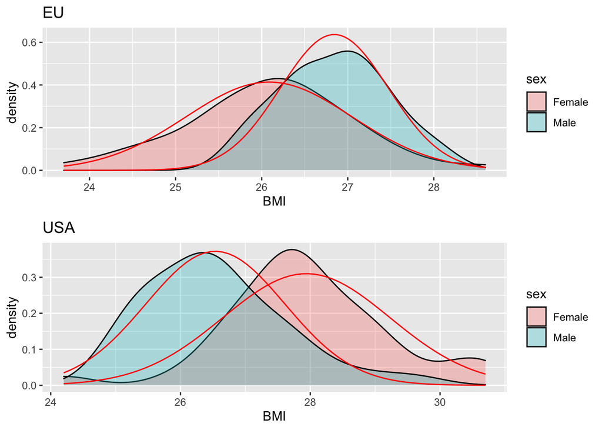

```r
plot_grid(EU_dist, USA_dist,
          ncol = 1)
```

**Q1 answer:** According to the graph above. The BNI of males and females in different region fellow the normal distribution.

## Q2: Test whether BMIs differ significantly between the Americas and European? Which test did you use & why? Also make a statement about the effect size.

To see whether the BMIs have significantly difference between Americas and European, we need to consider whether we need to use **t-test** or **Wilcoxon-rank sum test**.

**t-test** is only for the samples that is normal distribution. **Wilcoxon-rank sum test** is non-parametric version of the t-test.

Thus, we need to first see whether the samples are normal distribution or not. There are several ways to see whether the samples are normal distribution or not. We will use **Shapiro-Wilk normality test** here. If function `shapiro.test` shows the p-value > 0.05, it means it is normal distribution.

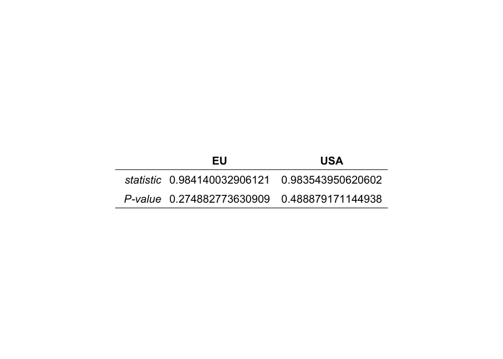

```r
USA_EU_bmi_data <- bmi_data %>%
  filter(REGION == "EUR" |REGION == "AMR")

summary_BMI_EU_USA <- data.frame(EU =c(shapiro.test(EU_bmi_data$BMI)$statistic,
                                       shapiro.test(EU_bmi_data$BMI)$p.value),
                                 USA = c(shapiro.test(USA_bmi_data$BMI)$statistic,
                                         shapiro.test(USA_bmi_data$BMI)$p.value)
                                 )
rownames(summary_BMI_EU_USA) <- c("statistic", "P-value")

#ggtexttable function is from ggpubr package to plot the table
ggtexttable(summary_BMI_EU_USA, theme = ttheme("light"))
```

**Q2 answer:** From the table above, it shows that the p-value is upper than 0.05. We can assume that the distribution is normal. Thus, we can use t-test to see the difference between region. Besides, because samples are from different regions, I assume they are independent cases; therefore, I won’t use paired t-test here.

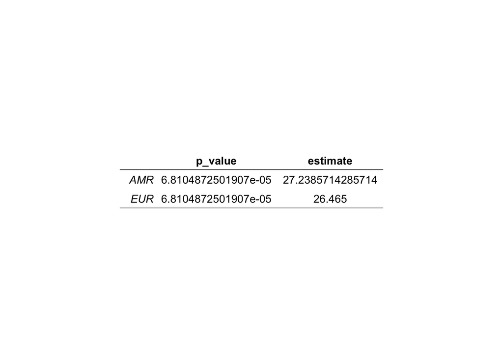

```r
t.test(BMI ~REGION, USA_EU_bmi_data)

t_test_USA_EU <- data.frame(p_value =t.test(BMI ~REGION, USA_EU_bmi_data)$p.value,
                            estimate =t.test(BMI ~REGION, USA_EU_bmi_data)$estimate)

rownames(t_test_USA_EU) <- c("AMR", "EUR")

ggtexttable(t_test_USA_EU, theme = ttheme("light"))
```

**Q2 answer:** P-value is lower than 0.05. Thus, there is significantly difference between Americas and European.

# Packages & R verion